# Analysis of Crime Data in Los Angeles from 2020 to 2024

### 13 March 2025

## **Introduction**

Crime analysis is vital in shaping public safety policies, optimizing law enforcement resource allocation, and improving urban planning. This study analyzes crime trends in Los Angeles from 2020 to 2024, utilizing data obtained from the LA Crime Open Data Portal. The primary goal is to uncover patterns related to the timing of crimes, their geographic distribution, and the most commonly reported offenses. Through exploratory data analysis (EDA), this project aims to identify high-crime areas, seasonal trends, and demographic factors influencing crime occurrences.

This study seeks to answer three key questions:

1. When do most crimes occur? (Analyzing crime timing patterns by time of day, month, and year)
2. Where do crimes happen most frequently? (Conducting geospatial analysis of crime locations)
3. What are the most common types of crimes? (Identifying major crime categories and trends over time)

[figure not shown]

## **Data Explained**

The dataset was obtained from the [LA Crime Open Data Portal](https://catalog.data.gov/dataset/crime-data-from-2020-to-present). According to data from data.gov **(Update as of January 18, 2024)**, the LAPD is currently facing challenges in posting crime data and is working diligently to resolve these issues. As a result, they are updating the data every **two weeks instead of weekly**, which has led to 2024 data being less comprehensive than in previous years. Thank you for your understanding. It contains over **1,000,000 records** of reported crimes in Los Angeles from **2020 to 2024**. It includes essential information such as the type of crime, location, victim demographics, and time of occurrence.

**The steps for data cleansing for this analysis included:**

- Removed missing values in critical columns (e.g., crime type, date, location).
- Converted date and time columns to proper datetime formats.
- Filtered out invalid victim ages (e.g., 0 or negative values).
- Standardized categorical values (e.g., gender, ethnicity).

**Seasons were defined as follows:**

- Winter: January, February, and December
- Spring: March, April, and May
- Summer: June, July, and August
- Fall: September, October, and November

### Data Dictionary:

| Measure Name | Description | Datatype |
| --- | --- | --- |
| Case_Number | The Official file number | int64 |
| Date_Reported | Date of crime report | object |
| Date_Occurred | Date of crime occurrence(YYYY-MM-DD) | datetime64[ns] |
| Time_Occurred | Time of crime occurrence | int64 |
| Area_Name | The 21 Geographic Areas or Patrol Divisions . | object |
| Rpt Dist No | Code representing a sub-area within a Geographic Area. | int64 |
| Crime_Code | Code representing the type of crime committed | int64 |
| Crime_Description | What kind of crime was committed | object |
| Victim_Age | Indicates the age of the victim. | int64 |
| Victim_Sex | F: Female M: Male | object |
| Victim_Ethnicity | The race description of Victim | object |
| Premises_Code | The code used for that premises | float64 |
| Premises_Description | The description of the area | object |
| Weapon_Description | Defines the Weapon Used Code provided. | object |
| Case_Status | The Status of the case | object |
| Case_Status_Description | The description of the case status | object |
| Crm Cd 1 | Indicates the crime committed. | float64 |
| LOCATION | Street address of crime incident . | object |
| Latitude | Latitude Coordinate | float64 |
| Longitude | Longitude Coordinate | float64 |
| Year | The year of occurrence | int64 |
| Month | The month of occurrence | Object |
| Weapon_Used | Checking if a weapon was used or not | int64 |
| Season | The season of crime occurrence: Winter, Spring, Fall, Summer | Object |

## **Results**

```python
#Load up modules
import pandas as pd
import numpy as np

#Load up visuals
import seaborn as sns
import matplotlib.pyplot as plt
import plotly.express as px

#set up notebook to display multiple output in one cell
from IPython.core.interactiveshell import InteractiveShell
InteractiveShell.ast_node_interactivity = "all"
```

```python
#read in final files
df = pd.read_csv("Cleaned_Crime_Data_Final.csv")

#show file
df.info()
```

```
<class 'pandas.core.frame.DataFrame'>
RangeIndex: 724907 entries, 0 to 724906
Data columns (total 25 columns):
 #   Column                   Non-Null Count   Dtype
---  ------                   --------------   -----
 0   Case_Number              724907 non-null  int64
 1   Date_Reported            724907 non-null  object
 2   Date_Occurred            724907 non-null  object
 3   Time_Occurred            724907 non-null  object
 4   Area_Name                724907 non-null  object
 5   Rpt Dist No              724907 non-null  int64
 6   Crime_Code               724907 non-null  int64
 7   Crime_Description        724907 non-null  object
 8   Victim_Age               724907 non-null  int64
 9   Victim_Sex               724907 non-null  object
```

[output cut: 17 more lines]

### **Geospatial Crime Hotspots and Top 10 Crime Areas in Los Angeles**

To establish a geographic context, we begin by **mapping crime locations** across Los Angeles. This visualization helps identify high-crime areas, which is essential for law enforcement resource allocation and urban safety planning.

#### **Observation:**

- The **highest concentrations** of crime reports are seen in **Central LA, 77th Street, and Pacific**, aligning with the expectation that **densely populated areas** experience more crime.
- This supports the hypothesis that **certain areas in LA have persistently high crime rates**.
- Particularly in locations with commercial activity, nightlife, and high residential density.

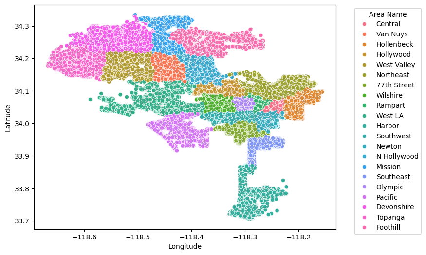

```python
df_subset = df[['Latitude','Longitude','Area_Name']]
df_subset.head()

df_subset = df_subset[(df_subset['Latitude'].between(33, 35)) &
                      (df_subset['Longitude'].between(-119, -117))]
#plot
fig, ax = plt.subplots(figsize=(8,6))
ax = sns.scatterplot(x='Longitude', y='Latitude', hue='Area_Name', data=df_subset, legend='full')
plt.legend(title='Area Name', bbox_to_anchor=(1.05, 1), loc='upper left')

plt.show();
```

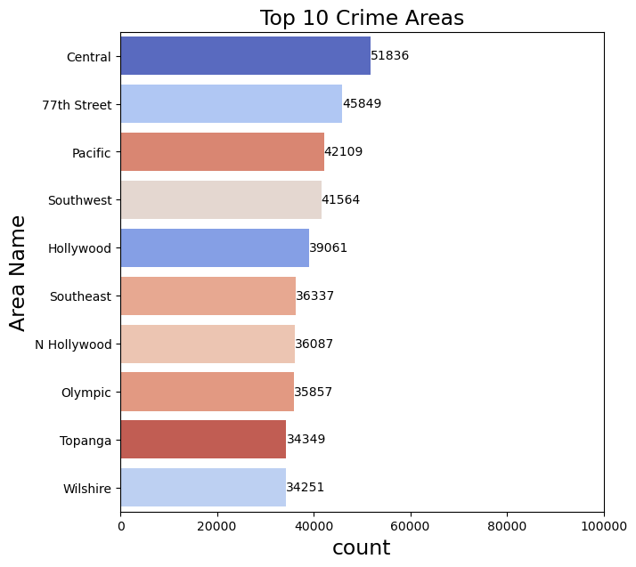

```python
# Displaying only top 10 crime Areas.
plt.figure(figsize=(7, 7))

top_10_crimes = df['Area_Name'].value_counts().nlargest(10)

crime_plot = sns.countplot(data = df, y='Area_Name',hue='Area_Name',order=top_10_crimes.index, palette = 'coolwarm',legend = False)

plt.title('Top 10 Crime Areas', fontsize = 17)
plt.xlabel('count', fontsize = 17)
plt.ylabel('Area Name', fontsize = 17)
plt.xlim(0, 100000)

for bar in crime_plot.patches:
    plt.text(
        bar.get_width(),
        bar.get_y() + bar.get_height() / 2,
        f'{int(bar.get_width())}',
        va='center'
    )
plt.show();
```

## Crime Timing Analysis: When Do Crimes Occur?**

#### **Observation:**

**Peak Times:** The most common times for crimes are

- **12 PM (Noon)** – This is the peak period for criminal activity, likely due to theft and robbery.
- **6 PM and 8 PM** – There is an increase in criminal activity during these hours as people are commuting home.
- **5 PM and 10 PM** – Crimes are often associated with nightlife, coinciding with reduced law enforcement presence.

**Seasonal Trends:** Crime rates are highest in spring and winter, with an uptick in offenses during these colder months.

```python
crime_on_Time = df['Victim_Age'].groupby(df['Time_Occurred']).agg(['mean','count'])

crime_Time = crime_on_Time.sort_values(by=('count'), ascending = False)[:5]

# Apply background gradient for visualization
crime_Time.style.background_gradient(cmap='Greens')

crime_on_Time = df['Victim_Age'].groupby(df['Time_Occurred']).count()
crime_on_Time
```

| Time_Occurred | mean | count |
| --- | --- | --- |
| 12:00 PM | 41.950878 | 26241 |
| 06:00 PM | 40.262545 | 16481 |
| 08:00 PM | 38.924124 | 15947 |
| 05:00 PM | 41.047679 | 15877 |
| 10:00 PM | 38.471992 | 14460 |

```
Time_Occurred
01:00 AM     8420
01:00 PM    11540
01:01 AM       78
01:01 PM       55
01:02 AM       44
            ...
12:57 PM       86
12:58 AM       51
12:58 PM       69
12:59 AM       44
12:59 PM       67
Name: Victim_Age, Length: 1439, dtype: int64
```

```python
# Without age restriction here's the Time_occurred hourly. To show when crime is the highest
df['Hour'] = pd.to_datetime(df['Time_Occurred'], format='%I:%M %p', errors='coerce').dt.strftime('%I %p')
crime_on_Time = df.groupby('Hour')['Victim_Age'].count().sort_values(ascending=False)[:5]
crime_on_Time
```

```
Hour
12 PM    52054
06 PM    40767
05 PM    40413
08 PM    39297
03 PM    38048
Name: Victim_Age, dtype: int64
```

```python
df_crosstab = pd.DataFrame(pd.crosstab(df['Crime_Description'], df['season']))

# Add a Total column summing all seasons
df_crosstab['Total'] = df_crosstab['Fall'] + df_crosstab['Spring'] + df_crosstab['Summer'] + df_crosstab['Winter']

# Sort by Total in descending order and keep only the top 10
df_crosstab = df_crosstab.sort_values(by='Total', ascending=False).head(10)

# Display with color formatting
df_crosstab.style.background_gradient(cmap='coolwarm')
```

| season Crime_Description | Fall | Spring | Summer | Winter | Total |
| --- | --- | --- | --- | --- | --- |
| BATTERY - SIMPLE ASSAULT | 17615 | 18928 | 18425 | 18631 | 73599 |
| BURGLARY FROM VEHICLE | 14975 | 15113 | 14382 | 16801 | 61271 |
| THEFT OF IDENTITY | 14289 | 15516 | 14288 | 17057 | 61150 |
| ASSAULT WITH DEADLY WEAPON, AGGRAVATED ASSAULT | 12511 | 12904 | 13419 | 12181 | 51015 |
| THEFT PLAIN - PETTY ($950 & UNDER) | 11351 | 11376 | 11262 | 12373 | 46362 |
| INTIMATE PARTNER - SIMPLE ASSAULT | 10910 | 12029 | 11555 | 11725 | 46219 |
| VANDALISM - FELONY ($400 & OVER, ALL CHURCH VANDALISMS) | 10953 | 11546 | 11774 | 11057 | 45330 |
| BURGLARY | 8973 | 10172 | 8978 | 10667 | 38790 |
| THEFT FROM MOTOR VEHICLE - GRAND ($950.01 AND OVER) | 8618 | 8606 | 8046 | 9689 | 34959 |
| THEFT-GRAND ($950.01 & OVER)EXCPT,GUNS,FOWL,LIVESTK,PROD | 6807 | 6572 | 6805 | 7063 | 27247 |

```python
#Crosstab to show the count of crime for each months of the year. From 2020 to 2024. Results show January has the highest crimes count total of 68,153.
month_order = [
    "January", "February", "March", "April", "May", "June",
    "July", "August", "September", "October", "November", "December"]
Year_month = pd.crosstab(df['Month'],df['Year']).reset_index()
Year_month.index = pd.CategoricalIndex(Year_month['Month'], categories = month_order, ordered = True)
Year_month = Year_month.sort_index().reset_index(drop = True)

# Display with color formatting
Year_month.style.background_gradient(cmap='coolwarm')
```

| Year | Month | 2020 | 2021 | 2022 | 2023 | 2024 |
| --- | --- | --- | --- | --- | --- | --- |
| 0 | January | 14626 | 12331 | 13691 | 14785 | 12720 |
| 1 | February | 13587 | 11412 | 13381 | 13790 | 11798 |
| 2 | March | 12254 | 12348 | 14847 | 13921 | 10898 |
| 3 | April | 11525 | 12141 | 14914 | 13417 | 8507 |
| 4 | May | 12503 | 12965 | 15272 | 13653 | 5142 |
| 5 | June | 12426 | 13053 | 15338 | 13587 | 3794 |
| 6 | July | 12752 | 14412 | 14998 | 14381 | 3757 |
| 7 | August | 12648 | 13920 | 15161 | 14289 | 3685 |
| 8 | September | 11844 | 13901 | 14653 | 13638 | 3797 |
| 9 | October | 12262 | 14427 | 15397 | 14185 | 3833 |
| 10 | November | 11690 | 13676 | 13959 | 13122 | 3662 |
| 11 | December | 11811 | 13160 | 15151 | 13266 | 2844 |

### Most Common Crimes

We identify the **most frequent crimes in Los Angeles** and examine their relative occurrences. An analysis of crime descriptions revealed the ten most common crimes:

#### **Observation:**

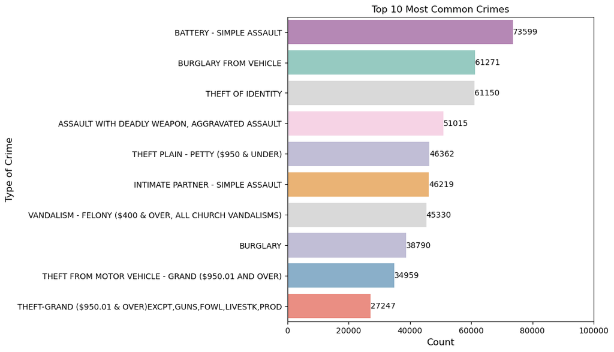

```python
# Displaying the top 10 most common type of crimes
plt.figure(figsize=(7, 7))

top_crimes = df['Crime_Description'].value_counts().nlargest(10)

crime_plot = sns.countplot(data=df, y = 'Crime_Description', hue = 'Crime_Description', legend=False, order=top_crimes.index, palette = 'Set3')

plt.title('Top 10 Most Common Crimes', fontsize = 12)
plt.xlabel('Count', fontsize = 12)
plt.ylabel('Type of Crime', fontsize = 12)
plt.xlim(0, 100000)

for bar in crime_plot.patches:
    plt.text(
        bar.get_width(),
        bar.get_y() + bar.get_height() / 2,
        f'{int(bar.get_width())}',
        va='center'
    )
plt.show();
```

### Trends over Time

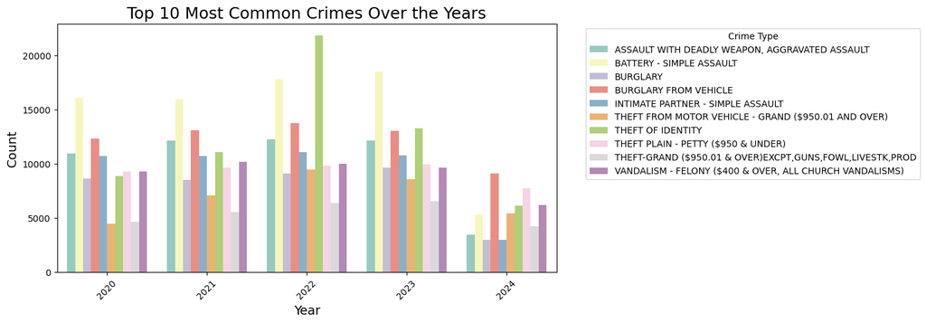

```python
plt.figure(figsize=(10,5))

# Counting occurrences of each Crime Type across all years
df_count = df.groupby('Crime_Description').size().reset_index(name='Total_Count')

# The top 10 crime types based on total occurrences
top_10_crimes = df_count.nlargest(10, 'Total_Count')['Crime_Description']

# Filtering to include only these top 10 crime types
df_top10 = df[df['Crime_Description'].isin(top_10_crimes)]

# Group by Year and Crime Type to count occurrences per year
df_top10_grouped = df_top10.groupby(['Year', 'Crime_Description']).size().reset_index(name='Count')

# Plot
sns.barplot(data=df_top10_grouped, x='Year', y='Count', hue='Crime_Description', palette='Set3')

plt.title('Top 10 Most Common Crimes Over the Years', fontsize=18)
plt.xlabel('Year', fontsize=14)
plt.ylabel('Count', fontsize=14)
plt.xticks(rotation=45)
plt.legend(title='Crime Type')

plt.legend(title='Crime Type', bbox_to_anchor=(1.05, 1), loc='upper left')
plt.show();
```

## Premise of the Top Crimes

Analysis of crime locations revealed that the **most frequent sites** for criminal activity were **single-family homes, streets, and multi-unit residences.**

#### **Observations:**

- Residential crimes tended to increase during the winter months, indicating a rise in burglary incidents around the holiday season.
- Public spaces such as parking lots and sidewalks were identified as hotspots for theft and assaults.

```python
df_crosstab= pd. DataFrame(pd. crosstab(df[ 'Premises_Description'],df ['season']))
# get a total count of reviews per Premises Description
df_crosstab[ 'Total'] = df_crosstab[ 'Fall'] + df_crosstab[ 'Spring'] + df_crosstab[ 'Summer'] + df_crosstab[ 'Winter']
df_crosstab = df_crosstab.sort_values(by='Total', ascending=False).head(5)
df_crosstab.style.background_gradient(cmap='Purples')
```

| season Premises_Description | Fall | Spring | Summer | Winter | Total |
| --- | --- | --- | --- | --- | --- |
| SINGLE FAMILY DWELLING | 37709 | 41290 | 38560 | 42434 | 159993 |
| STREET | 32507 | 33539 | 33571 | 34656 | 134273 |
| MULTI-UNIT DWELLING (APARTMENT, DUPLEX, ETC) | 26631 | 28760 | 27462 | 30151 | 113004 |
| PARKING LOT | 11168 | 11774 | 11334 | 12187 | 46463 |
| SIDEWALK | 9302 | 9530 | 9679 | 9176 | 37687 |

## Gender & Ethnicity

1. **Gender Analysis:**
   - The pie chart indicates that male victims (51.1%) slightly outnumber female victims (48.9%) in crime incidents.
2. **Ethnicity Analysis:**
   - The Hispanic/Latinx population reported the highest number of crime victims, followed by White and Black individuals.

#### **Observations:**

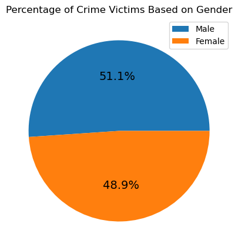

```python
labels = ['Male','Female']
counts = df['Victim_Sex'].value_counts()
counts = counts[counts > 100]

plt.figure(figsize=(5, 5))
plt.title('Percentage of Crime Victims Based on Gender')
plt.pie(counts, autopct='%1.1f%%', textprops={"fontsize":14})
plt.legend(labels, loc="best")
plt.show();
```

```python
crime_on_Ethnicity = df['Victim_Age'].groupby(df['Victim_Ethnicity']).agg(['mean','count'])

crime_Ethnicity = crime_on_Ethnicity.sort_values(by=('count'), ascending = False)[:5]

# Apply background gradient for visualization
crime_Ethnicity.style.background_gradient(cmap='Greens')
```

| Victim_Ethnicity | mean | count |
| --- | --- | --- |
| Hispanic/Latin/Mexican | 36.910739 | 291268 |
| White | 43.515353 | 186212 |
| Black | 39.455200 | 134073 |
| Other | 41.832969 | 64491 |
| Asian | 42.295707 | 20987 |

```python
crime_on_year = df['Year'].groupby(df['Victim_Age']).agg(['mean','count'])

crime_year = crime_on_year.sort_values(by=('count'), ascending = False)[:5]

# Apply background gradient for visualization
crime_year.style.background_gradient(cmap='Greens')
```

| Victim_Age | mean | count |
| --- | --- | --- |
| 30 | 2021.805188 | 22206 |
| 35 | 2021.833456 | 21772 |
| 31 | 2021.833068 | 21332 |
| 29 | 2021.811470 | 21238 |
| 28 | 2021.805364 | 20880 |

## **Summary**

This analysis of **Los Angeles crime data from 2020 to 2024** provides valuable insights into **when, where, and what types of crimes occur most frequently**.  
The findings reveal that **crime rates peak during spring and winter**, with **noon and evening hours experiencing the highest levels of criminal activity**.  
The **areas most affected include Central LA, 77th Street, and Pacific**, where crime density is greatest.  
Common crimes such as **assault, burglary, and theft-related offenses** continue to dominate, underscoring the need for effective law enforcement strategies.

### **Challenges**

**Underreporting**: Some crimes may not be officially reported, resulting in data gaps.  
**Data Incompleteness in 2024**: A noticeable drop in recorded crimes in 2024 likely stems from missing data rather than an actual reduction in crime rates.  
**Anonymized Geospatial Data**: Location data is generalized, which reduces the precision of mapping exact crime locations.

```python
df.to_csv("Cleaned_Crime_Data_FinalReport.csv", index=False)
```